# DAPR3 2627 Report - what we would do

Very first thing is just take a look at the data:

```r
library(tidyverse)
library(patchwork)
library(lme4)
library(lmerTest)
library(effects)
library(broom.mixed)
library(HLMdiag)

wally <- read_csv('https://uoepsy.github.io/dapr3/2627/report/dapr3_2627_report.csv')
head(wally)
```

```
# A tibble: 6 × 7
  ppt    group   age platform scene      n_chars TOTAL_FIXATIONS
  <chr>  <dbl> <dbl> <chr>    <chr>        <dbl>           <dbl>
1 PID001     1    19 iOS      Beach          300              36
2 PID001     1    19 iOS      Ski Resort     300              36
3 PID001     1    19 iOS      Fairground     300              32
4 PID001     1    NA <NA>     Airport         NA              NA
5 PID001     1    19 iOS      Wild West      350              50
6 PID001     1    19 iOS      Stone Age      350              42
```

**contrasts e-scaling the n_chars variable**

Let’s change things to factors, specifically the `group` variable. We’re going to want to compare everything against “standard”, because that’s how the predictions are framed, so let’s set that as the reference level.

```r
wally <-
  wally |> mutate(
    group = factor(group, levels=c(2,1,3),
                   labels = c("standard","desaturated","gridoverlay")),
    platform = factor(platform),
    scene = factor(scene)
  )
```

I’m also going to re-scale the`n_chars` predictor, so that it coefficients reflect change in fixations for every 100 additional characters (rather than every additional 1). I’ll also center it on 300, the least busy scene.

You don’t *have* to do this re-scaling right at the outset. It will probably help model convergence later on. Alternatively, you could leave it as is and re-scale it if needed for the model. And you don’t have to do this specific scaling, you could just Z-score it - the important thing is keeping track (and being clear in communication) about what “0” means on the scale, and what “moving 1” represents.

```r
wally <-
  wally |>
  mutate(
    # recenter on 300, scale to 100-characters
    n_chars = (n_chars/100) - 3
  )

summary(wally)
```

```
     ppt                    group          age           platform
 Length:720         standard   :240   Min.   :18.00   iOS    :533
 Class :character   desaturated:240   1st Qu.:19.00   Windows:115
 Mode  :character   gridoverlay:240   Median :22.00   NA's   : 72
                                      Mean   :21.97
                                      3rd Qu.:24.00
                                      Max.   :26.00
                                      NA's   :72
              scene        n_chars      TOTAL_FIXATIONS
 Airport         : 36   Min.   :0.000   Min.   : 5.00
 Airport Terminal: 36   1st Qu.:0.500   1st Qu.:34.00
 Beach           : 36   Median :1.000   Median :41.00
 Carnival        : 36   Mean   :1.014   Mean   :41.87
 Deep Sea        : 36   3rd Qu.:1.500   3rd Qu.:50.00
 Department Store: 36   Max.   :2.000   Max.   :73.00
 (Other)         :504   NA's   :72      NA's   :72
```

**initial descriptives**

Note there are 72 missing obs for each of age, platform, n_chars and TOTAL_FIXATIONS. We might want to look at that a little more shortly.

For starters, we have 36 people, and 20 scenes. Good, that’s what we’d been told:

```r
wally |> summarise(
  n_ppt = n_distinct(ppt),
  n_scene = n_distinct(scene),
  n_total = n(),
)
```

```
# A tibble: 1 × 3
  n_ppt n_scene n_total
  <int>   <int>   <int>
1    36      20     720
```

Lets describe the people.  
In this bit we’ll remove the NAs otherwise it creates multiple rows per person:

```r
wally |>
  filter(!is.na(age), !is.na(platform)) |>
  distinct(ppt, group, age, platform) |>
  summary()
```

```
     ppt                    group         age           platform
 Length:36          standard   :12   Min.   :18.00   iOS    :29
 Class :character   desaturated:12   1st Qu.:19.00   Windows: 7
 Mode  :character   gridoverlay:12   Median :22.00
                                     Mean   :21.97
                                     3rd Qu.:24.00
                                     Max.   :26.00
```

What about the missingness? How many trials does each person have fixation data for?

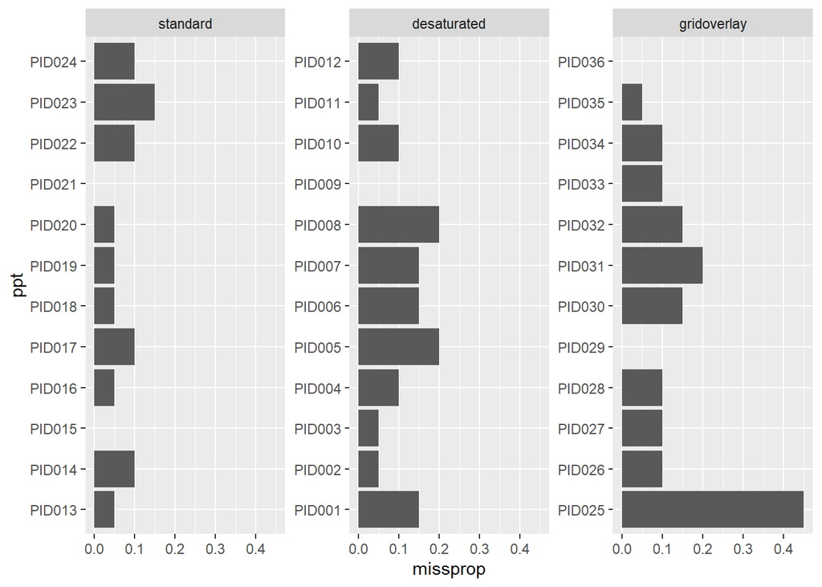

```r
wally |>
  group_by(group, ppt) |>
  summarise(
    # complete trials:
    ncomp = sum(!is.na(TOTAL_FIXATIONS)),
    # proportion missing:
    missprop = sum(is.na(TOTAL_FIXATIONS))/n(),
  ) |>
  ggplot(aes(x=ppt, y=missprop))+
  geom_col()+
  facet_wrap(~group,scales="free_y")+
  coord_flip()
```

the missingness seems to be spread fairly randomly across people from all three conditions. on avg people have ~10% of their trials missing.

It’s also worth checking the scenes too, in case there’s just a few scenes that seemed to not work with the webcam eye tracker

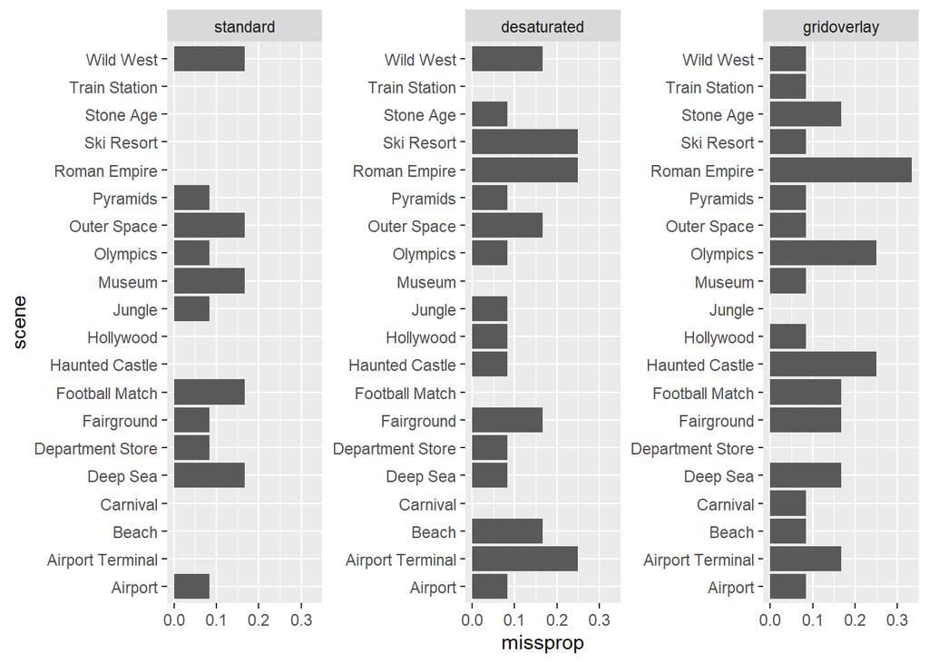

```r
wally |>
  group_by(group, scene) |>
  summarise(
    # complete trials:
    ncomp = sum(!is.na(TOTAL_FIXATIONS)),
    # proportion missing:
    missprop = sum(is.na(TOTAL_FIXATIONS))/n(),
  ) |>
  ggplot(aes(x=scene, y=missprop))+
  geom_col()+
  facet_wrap(~group,scales="free_y")+
  coord_flip()
```

- ppts have between 11 and 20 trials worth of data (median 18).
- one ppt has ~45% missing!
- scenes have between 8 and 12 observations in each condition.

Okay, let’s remove the missingness, and see how many things we’re working with:

```r
wally |>
  filter(!is.na(TOTAL_FIXATIONS)) |>
  summarise(
    n_ppt = n_distinct(ppt),
    n_scene = n_distinct(scene),
    n_total = n(),
)
```

```
# A tibble: 1 × 3
  n_ppt n_scene n_total
  <int>   <int>   <int>
1    36      20     648
```

We’ve gone down to 648 observations.

Because all of the missingness happens in the `TOTAL_FIXATIONS` variable, which is going to be our outcome, it means those rows will just be completely removed from the model.

So it might be worth us removing them now anyway..

```r
# keep the full one just in case
wally_full <- wally
# and here's the data with no missingness
wally <- wally |> filter(!is.na(TOTAL_FIXATIONS))
summary(wally)
```

```
     ppt                    group          age           platform
 Length:648         standard   :224   Min.   :18.00   iOS    :533
 Class :character   desaturated:214   1st Qu.:19.00   Windows:115
 Mode  :character   gridoverlay:210   Median :22.00
                                      Mean   :21.97
                                      3rd Qu.:24.00
                                      Max.   :26.00

              scene        n_chars      TOTAL_FIXATIONS
 Carnival        : 35   Min.   :0.000   Min.   : 5.00
 Train Station   : 35   1st Qu.:0.500   1st Qu.:34.00
 Department Store: 34   Median :1.000   Median :41.00
 Hollywood       : 34   Mean   :1.014   Mean   :41.87
 Jungle          : 34   3rd Qu.:1.500   3rd Qu.:50.00
 Airport         : 33   Max.   :2.000   Max.   :73.00
 (Other)         :443
```

How many observations for each ppt? and for each scene?

```r
wally |>
  filter(!is.na(TOTAL_FIXATIONS)) |>
  count(ppt) |>
  summary()
```

```
     ppt                  n
 Length:36          Min.   :11
 Class :character   1st Qu.:17
 Mode  :character   Median :18
                    Mean   :18
                    3rd Qu.:19
                    Max.   :20
```

between 11 and 20 per ppt, median 18

```r
wally |>
  filter(!is.na(TOTAL_FIXATIONS)) |>
  count(scene) |>
  summary()
```

```
              scene          n
 Airport         : 1   Min.   :29.00
 Airport Terminal: 1   1st Qu.:31.00
 Beach           : 1   Median :32.50
 Carnival        : 1   Mean   :32.40
 Deep Sea        : 1   3rd Qu.:33.25
 Department Store: 1   Max.   :35.00
 (Other)         :14
```

between 29 and 35 per scene, median 32.5

We might also want to check that all scenes were seen by each group.  
One way to look at that:

```r
wally |> filter(!is.na(TOTAL_FIXATIONS)) |>
  select(scene, group) |>
  table()
```

```
                  group
scene              standard desaturated gridoverlay
  Airport                11          11          11
  Airport Terminal       12           9          10
  Beach                  12          10          11
  Carnival               12          12          11
  Deep Sea               10          11          10
  Department Store       11          11          12
  Fairground             11          10          10
  Football Match         10          12          10
  Haunted Castle         12          11           9
  Hollywood              12          11          11
  Jungle                 11          11          12
  Museum                 10          12          11
  Olympics               11          11           9
  Outer Space            10          10          11
  Pyramids               11          11          11
  Roman Empire           12           9           8
  Ski Resort             12           9          11
  Stone Age              12          11          10
  Train Station          12          12          11
  Wild West              10          10          11
```

**exploring what predictors varies by which groups**

To help me keep track of what could be in random effects etc, I like to plot things facetted by the groups. We have both groupings of both participants and scenes here.

We could do tables here instead, like we’ve seen (using `xtabs()` but really it’s all just the same idea of seeing what predictors vary *between* groups and what predictors vary *within* groups).

If we plot n_chars on the x, and TOTAL_FIXATIONS on the y, we can see that this varies *within* participants, but *between* scenes:

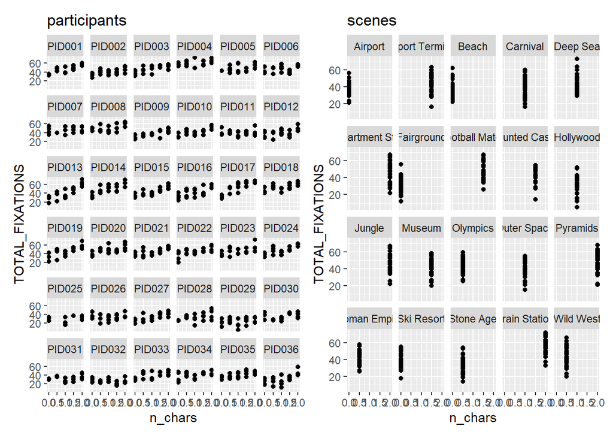

```r
ggplot(wally, aes(x=n_chars, y=TOTAL_FIXATIONS))+
  geom_point()+
  facet_wrap(~ppt)+
  labs(title="participants") +

  ggplot(wally, aes(x=n_chars, y=TOTAL_FIXATIONS))+
  geom_point()+
  facet_wrap(~scene)+
  labs(title="scenes")
```

And if we do the same for the group (standard, desaturated, gridoverlay), it’s the other way around:

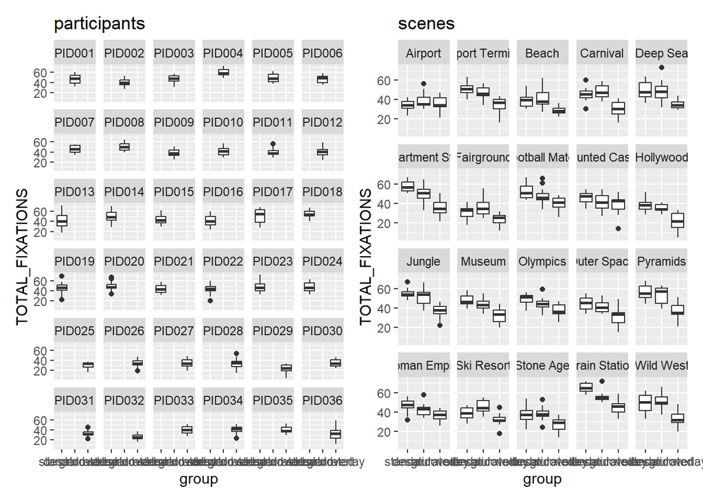

```r
ggplot(wally, aes(x=group, y=TOTAL_FIXATIONS))+
  geom_boxplot()+
  facet_wrap(~ppt)+
  labs(title="participants") +

  ggplot(wally, aes(x=group, y=TOTAL_FIXATIONS))+
  geom_boxplot()+
  facet_wrap(~scene)+
  labs(title="scenes")
```

(I’d probably want to tidy up the axes so they are readable if I plan on showing a reader these plots, but they’re really just for my own exploration here)

**building a model**

Let’s make a model!

We’re interested in TOTAL_FIXATIONS ~ n_chars * group.  
this is whether the change in fixations as a scene gets busier (n_chars) is different depending on which condition people are in (desaturated, colour, etc).

We have multiple observations per person, and multiple observations per scene. n_chars varies between the scenes, but within people, and the group varies between people but within scenes.

So we can try this:

```r
mod_wally <-
  lmer(TOTAL_FIXATIONS ~ 1 + n_chars * group +
       (1 + n_chars | ppt) +
       (1 + group | scene),
     data = wally)
```

And it converges! hooray!

Note that if we *hadn’t* re-scaled `n_chars`, then it probably throws an error.

```r
# undoing the transformation we did earlier:
wally <- wally |>
  mutate(
    n_chars_original = (n_chars + 3)* 100
  )

mod_wally_noscale <-
  lmer(TOTAL_FIXATIONS ~ 1 + n_chars_original * group +
       (1 + n_chars_original | ppt) +
       (1 + group | scene),
     data = wally)
```

We could just as easily use a z-scored version of `n_chars`, it would then converge

```r
wally <- wally |>
  mutate(
    n_chars_z = (n_chars - mean(n_chars, na.rm=TRUE))/sd(n_chars, na.rm=TRUE)
  )

mod_wally_z <-
  lmer(TOTAL_FIXATIONS ~ 1 + n_chars_z * group +
       (1 + n_chars_z | ppt) +
       (1 + group | scene),
     data = wally)
```

there’s a slight disadvantage to z-scoring here. For interpretation, it’s useful to know what “0” and “moving 1” mean in reality - i.e., in the context of the experiment.

```r
mean(wally$n_chars_original)
```

```
[1] 401.3889
```

```r
sd(wally$n_chars_original)
```

```
[1] 71.18722
```

What this means is that some of our fixed effects coefficients will be *specifically* for scenes with 401.4 characters in them (I’m kind of fine with just saying ~400). It will also mean that some of the coefficients tell us the change in average fixations when we add 71.2 characters.  
That feels a bit odd to me?  
And if we forget to tell the reader what 0 and 1 now mean, they’ll never actually know that it is “adding 71.2 characters”..

**what about age and platform?**

Not everything in the data needs to be in the model. Because we are running a randomised experiment here, where everyone sees all of the `n_chars` values, and people are randomly allocated into the conditions (desaturated, standard, grid-overlay), it means that whether we include/exclude things like `age` and `platform` will not bias our estimates. It would only become a problem if something like age influenced what condition people are in (and also influenced their visual search efficiency).  
So essentially - this model would also be fine:

```r
mod_wally_covars <-
  lmer(TOTAL_FIXATIONS ~ 1 + age + platform + n_chars * group +
       (1 + n_chars | ppt) +
       (1 + group | scene),
     data = wally)

# note that the effects we are interested in haven't changed much:
fixef(mod_wally)
```

```
             (Intercept)                  n_chars         groupdesaturated
               36.837781                 9.971552                 3.352932
        groupgridoverlay n_chars:groupdesaturated n_chars:groupgridoverlay
               -7.343313                -4.980792                -5.988778
```

```r
fixef(mod_wally_covars)
```

```
             (Intercept)                      age          platformWindows
             37.72278647              -0.03384212              -0.56238755
                 n_chars         groupdesaturated         groupgridoverlay
              9.97165039               3.26300058              -7.35295866
n_chars:groupdesaturated n_chars:groupgridoverlay
             -4.98117561              -5.98729077
```

what we probably **don’t** want to try, is putting `age` and `platform` in as grouping variables like

```
..... (1 + .... | age ) + (1 + ..... | platform)
```

Why not? although age captures groups (18,19,20,…) and so on, any variability this creates in the outcome we would expect to be reproducible (such that higher values tend to correspond with less efficient search). So even if we get different groups the next time round (we could get 26,27,28, year olds), this would lead to the same systematic influence on visual search (higher age, poorer searching). So if we want to include `age` in the model, it would be much more appropriate to think of it as a reproducible slope such that “1 year older >> X more fixations”, rather than “the randomly sample age group you are in will have a higher/lower nr fixations”.

Similarly, *if* there *are* any platform differences in visual search efficiency, then we would expect these to come out again if we repeated the experiment on a new sample (we would still get Windows & iOS users, and still get the avg differences between the platforms). On a more practical note, there are only 2 levels here, and using a random effect `(1 | g)` tries to estimate a variance across the levels of `g`. Estimating a variance in 2 groups is actually just the same thing as estimating the difference.

**assumptions etc?**

Residual plots look okay. some of the scene random slopes are a bit off, but there are only 20 scenes, so maybe this isn’t too bad..

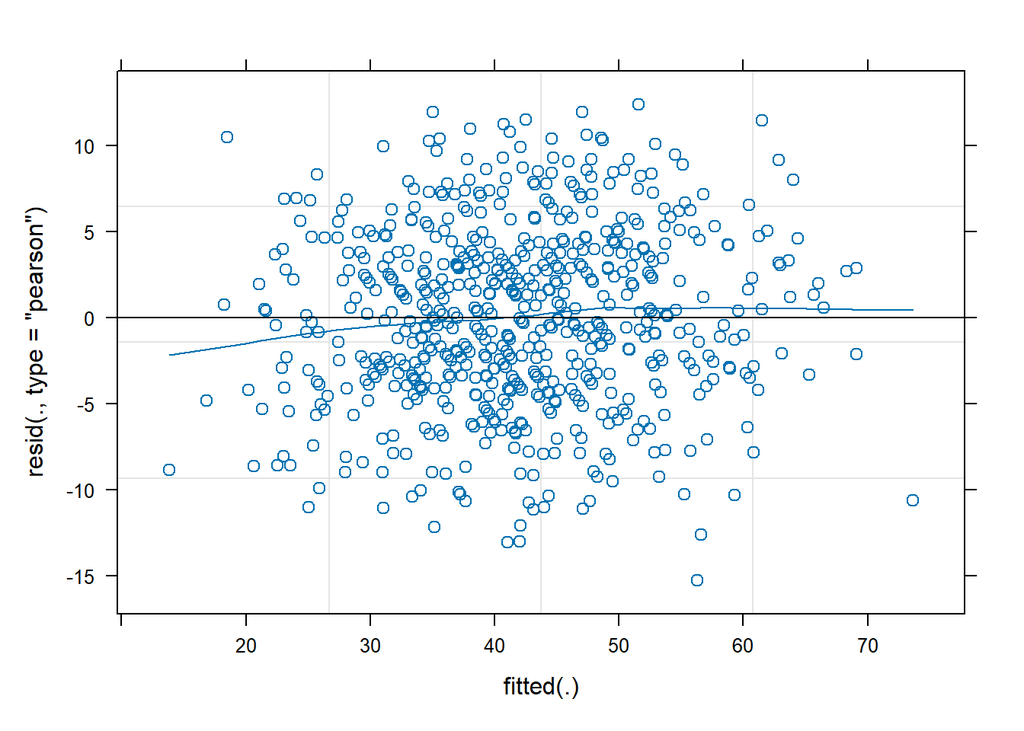

```r
plot(mod_wally, type=c("p","smooth"))
```

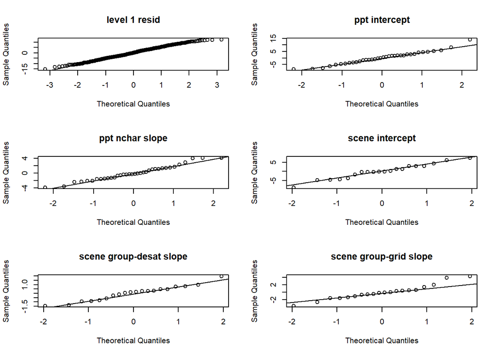

```r
par(mfrow=c(3,2))
qqnorm(resid(mod_wally),main="level 1 resid")
qqline(resid(mod_wally))

qqnorm(ranef(mod_wally)$ppt[,1],main="ppt intercept")
qqline(ranef(mod_wally)$ppt[,1])
qqnorm(ranef(mod_wally)$ppt[,2],main="ppt nchar slope")
qqline(ranef(mod_wally)$ppt[,2])

qqnorm(ranef(mod_wally)$scene[,1],main="scene intercept")
qqline(ranef(mod_wally)$scene[,1])
qqnorm(ranef(mod_wally)$scene[,2],main="scene group-desat slope")
qqline(ranef(mod_wally)$scene[,2])
qqnorm(ranef(mod_wally)$scene[,3],main="scene group-grid slope")
qqline(ranef(mod_wally)$scene[,3])
```

and check for influence:

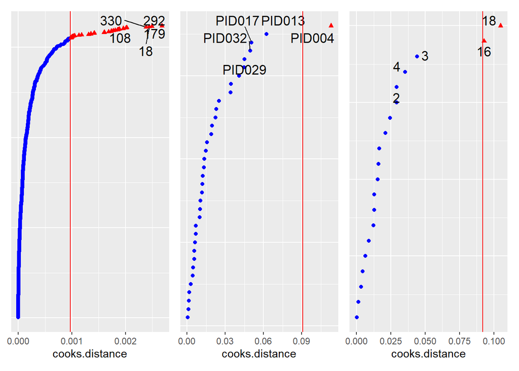

```r
inf_obs  <- hlm_influence(model = mod_wally, level = 1, approx = TRUE)
inf_ppt <- hlm_influence(model = mod_wally, level = "ppt", approx = TRUE)
inf_scene <- hlm_influence(model = mod_wally, level = "scene", approx = TRUE)

dotplot_diag(inf_obs$cooksd, cutoff="internal") +
dotplot_diag(inf_ppt$cooksd, index=inf_ppt$ppt, cutoff="internal") +
dotplot_diag(inf_scene$cooksd, index=inf_ppt$scene, cutoff="internal")
```

No conclusions change:

```r
mod_wally_subp4 <-
  lmer(TOTAL_FIXATIONS ~ 1 + n_chars * group +
       (1 + n_chars | ppt) +
       (1 + group | scene),
     data = wally |> filter(ppt != "PID004"))

mod_wally_subs1618 <-
  lmer(TOTAL_FIXATIONS ~ 1 + n_chars * group +
       (1 + n_chars | ppt) +
       (1 + group | scene),
     data = wally |> filter(scene!="Train Station", scene!="Airport"))

sjPlot::tab_model(
  mod_wally,
  mod_wally_subp4,
  mod_wally_subs1618,
  show.re.var=FALSE, show.icc=FALSE,
  show.r2=FALSE
)
```

|  | TOTAL FIXATIONS |  |  | TOTAL FIXATIONS |  |  | TOTAL FIXATIONS |  |  |
| --- | --- | --- | --- | --- | --- | --- | --- | --- | --- |
| Predictors | Estimates | CI | p | Estimates | CI | p | Estimates | CI | p |
| (Intercept) | 36.84 | 32.24 – 41.43 | **<0.001** | 36.83 | 32.52 – 41.14 | **<0.001** | 37.79 | 33.16 – 42.41 | **<0.001** |
| n chars | 9.97 | 6.79 – 13.15 | **<0.001** | 9.97 | 6.78 – 13.16 | **<0.001** | 8.68 | 5.31 – 12.05 | **<0.001** |
| group [desaturated] | 3.35 | -1.34 – 8.04 | 0.161 | 1.87 | -2.40 – 6.14 | 0.389 | 3.08 | -1.73 – 7.90 | 0.209 |
| group [gridoverlay] | -7.34 | -12.33 – -2.35 | **0.004** | -7.33 | -11.79 – -2.87 | **0.001** | -8.91 | -13.79 – -4.04 | **<0.001** |
| n chars × group [desaturated] | -4.98 | -7.57 – -2.39 | **<0.001** | -4.82 | -7.54 – -2.09 | **0.001** | -4.60 | -7.61 – -1.58 | **0.003** |
| n chars × group [gridoverlay] | -5.99 | -8.93 – -3.05 | **<0.001** | -5.99 | -8.95 – -3.03 | **<0.001** | -4.92 | -8.00 – -1.85 | **0.002** |
| N | 36 <sub>ppt</sub> |  |  | 35 <sub>ppt</sub> |  |  | 36 <sub>ppt</sub> |  |  |
|  | 20 <sub>scene</sub> |  |  | 20 <sub>scene</sub> |  |  | 18 <sub>scene</sub> |  |  |
| Observations | 648 |  |  | 630 |  |  | 580 |  |  |

And if we want to go a bit more in depth.. the train station scene is particularly difficult! possibly more competing colour distractions in there - note it has a smaller effect of desaturation. by contrast, the hollywood scene is easy.  
and participant 4 was just quite bad at searching!

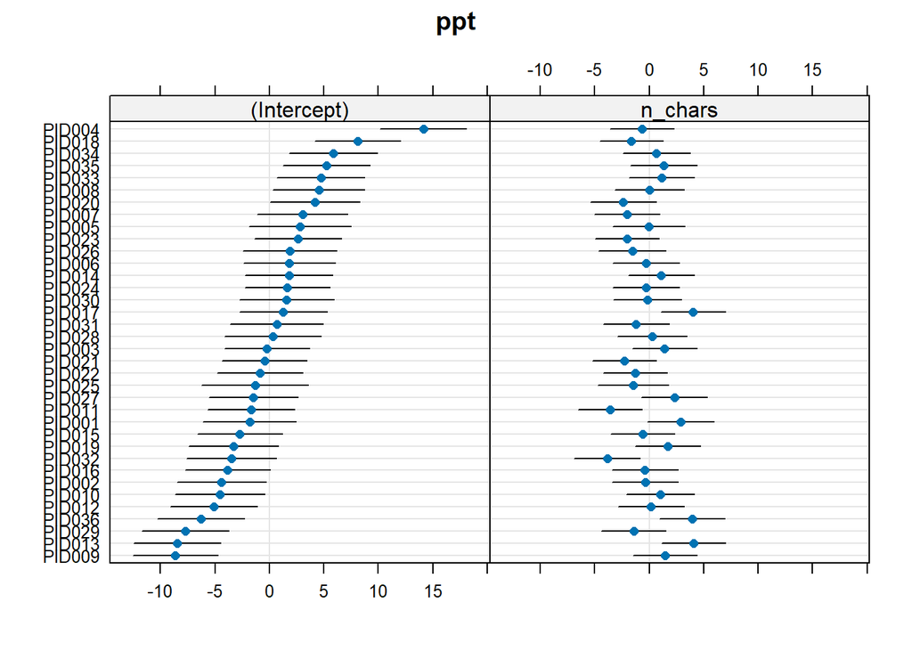

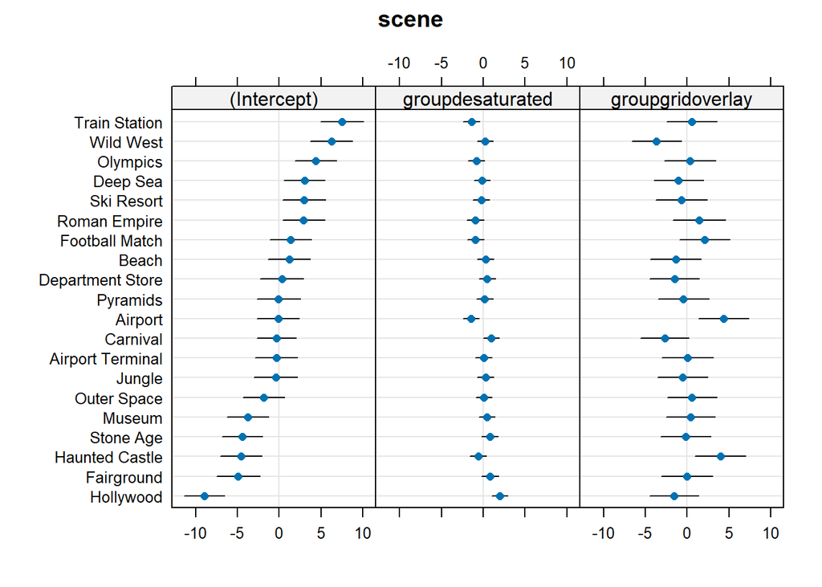

```r
dotplot.ranef.mer(ranef(mod_wally))
```

**visualising the model**

Okay, I’m happy with the model, so let’s do some visualising.

Quick and easy would be:

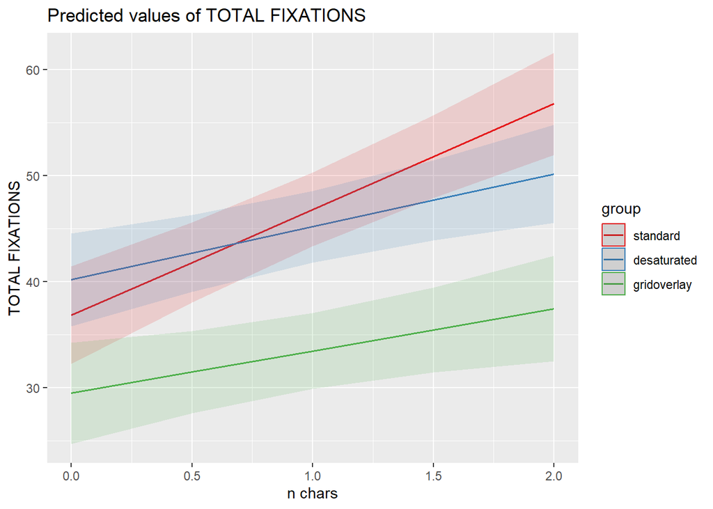

```r
library(sjPlot)
plot_model(mod_wally, type = "int")
```

I’ve gone a bit more involved here than is probably necessary, and added the participant-level average fitted values in as well as the fixed effects:

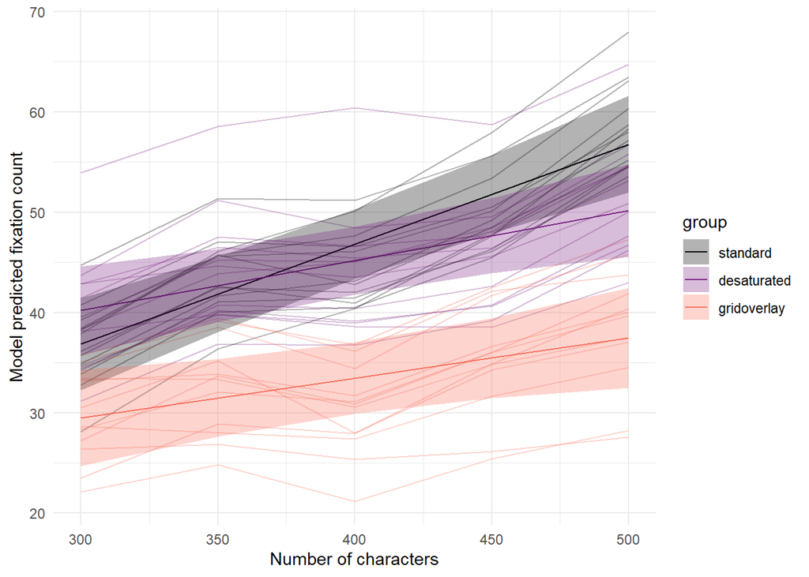

Figure 1: Model estimated differences in fixations across number of characters for each condition. Individual lines represent participant-level fitted values

```r
pfix <- effect("n_chars*group", mod_wally) |>
  as.data.frame()

augment(mod_wally) |>
  group_by(group, ppt, n_chars) |>
  summarise(
    .fitted = mean(.fitted)
  ) |>
  ggplot(aes(x = n_chars, col=group)) +
  geom_line(aes(y = .fitted, group = ppt), alpha=.3) +
  geom_line(data = pfix,
            aes(y = fit, col = group)) +
  geom_ribbon(data = pfix,
              aes(ymin=lower,ymax=upper,fill=group),
              col=NA, alpha=.3) +
  scale_fill_viridis_d(option="A",begin=0,end=.7) +
  scale_color_viridis_d(option="A",begin=0,end=.7) +
  theme_minimal()+
  scale_x_continuous(
    "Number of characters",
    breaks = seq(0,2,.5),
    labels = seq(300,500,50))+
  labs(y="Model predicted fixation count")
```

**interpreting**

```r
summary(mod_wally, corr = FALSE)
```

```
Linear mixed model fit by REML. t-tests use Satterthwaite's method [
lmerModLmerTest]
Formula: TOTAL_FIXATIONS ~ 1 + n_chars * group + (1 + n_chars | ppt) +
    (1 + group | scene)
   Data: wally

REML criterion at convergence: 4258.2

Scaled residuals:
     Min       1Q   Median       3Q      Max
-2.73042 -0.64702 -0.02075  0.66817  2.21555

Random effects:
 Groups   Name             Variance Std.Dev. Corr
 ppt      (Intercept)      28.0151  5.2929
          n_chars           6.3534  2.5206   -0.35
 scene    (Intercept)      18.1502  4.2603
          groupdesaturated  0.9818  0.9909   -0.55
          groupgridoverlay  6.0789  2.4655   -0.17 -0.73
 Residual                  31.3450  5.5987
Number of obs: 648, groups:  ppt, 36; scene, 20

Fixed effects:
                         Estimate Std. Error     df t value Pr(>|t|)
(Intercept)                36.838      2.339 38.740  15.748  < 2e-16 ***
n_chars                     9.972      1.620 26.372   6.157 1.55e-06 ***
groupdesaturated            3.353      2.388 34.428   1.404 0.169243
groupgridoverlay           -7.343      2.542 38.446  -2.889 0.006316 **
n_chars:groupdesaturated   -4.981      1.318 33.939  -3.779 0.000608 ***
n_chars:groupgridoverlay   -5.989      1.496 33.342  -4.002 0.000330 ***
---
Signif. codes:  0 '***' 0.001 '**' 0.01 '*' 0.05 '.' 0.1 ' ' 1
```

Here’s what each of our coefficients represent.

**random effects**

**Findings**

So we have an overarching research question:

> RQ: Does the decrease in visual search efficiency due to number of distractor characters differ between the three conditions?

And 3 specific predictions to talk about:

> 1. In the “standard colour” condition, people will be less efficient at visually searching scenes with greater numbers of characters.
> 2. The effect of character number could plausibly be smaller in the “grid overlay” condition, because the grid might help people search systematically.
> 3. The effect of character number could plausibly be larger in the “desaturated” condition, because removing colour might remove a useful search cue.

For the overall RQ, we can see our answer in the interaction coefficients. If either of them is significant, then we have reason to reject the null hypothesis (that there is no difference between conditions in the effect of number of characters on visual search).

And if we want to really drive this home, we can do an test of both of the interaction terms jointly, as a whole, by comparing our model to a model without the interaction.

```r
mod_wally_noint <-
  lmer(TOTAL_FIXATIONS ~ 1 + n_chars + group +
       (1 + n_chars | ppt) +
       (1 + group | scene),
     data = wally)


anova(mod_wally_noint, mod_wally)
```

```
Data: wally
Models:
mod_wally_noint: TOTAL_FIXATIONS ~ 1 + n_chars + group + (1 + n_chars | ppt) + (1 + group | scene)
mod_wally: TOTAL_FIXATIONS ~ 1 + n_chars * group + (1 + n_chars | ppt) + (1 + group | scene)
                npar    AIC    BIC  logLik -2*log(L)  Chisq Df Pr(>Chisq)
mod_wally_noint   14 4320.7 4383.3 -2146.3    4292.7
mod_wally         16 4306.2 4377.7 -2137.1    4274.2 18.532  2  9.456e-05 ***
---
Signif. codes:  0 '***' 0.001 '**' 0.01 '*' 0.05 '.' 0.1 ' ' 1
```

It’s significant, which gives us our ability to say that there is a significant difference between conditions in the effect of number of characters on visual search!

And in relation to our specific predictions:

Prediction 1 is supported by the significant and positive coefficient for `n_chars`, showing fixations increase (less efficient searching) with more characters in the standard condition

Prediction 2 is supported by the interaction coefficient for `n_chars:groupgridoverlay`, which is significant and negative, meaning the effect of n_chars is smaller than it is in the standard condition

Prediction 3 is not supported - the interaction for `n_chars:griddesaturated` is negative and significant. it actually suggests the opposite direction of the prediction - desaturation appears to reduce the effect of scene-busyness on search efficiency.